# DESeq2

2025-05-08

```r
library(DESeq2)
# gene enrichment libraries
library(clusterProfiler)
```

```r
library(msigdb)
library(enrichplot)
# plotting libraries:
library(ggplot2)
library(ggrepel)
library(RColorBrewer)
library(pheatmap)

counts_f <- '/home/stud0/aibh_integromics/05_deseq/data/counts_HX.tsv.gz'
gene_len_f <- '/home/stud0/aibh_integromics/05_deseq/data/gene_lengths.txt'
hallmark_rds <- '/home/stud0/aibh_integromics/05_deseq/data/hallm.rds'
```

## Differential expression lab

We have a dataset with colorectal cancer samples (n=9) collected from human tumors (n=4) and some derived xenografts (n=5), we want to identify the DEG between these two groups and determine if the FPKM normalization leads to the expected bias with respect to the DESeq2 one due to genes expressed only in the human tumors (why do we expect them?).

## Loading data, initial lowly expressed genes filtering evaluation

See ‘Pre-filtering’ here for more info: https://bioconductor.org/packages/devel/bioc/vignettes/DESeq2/inst/doc/DESeq2.html, this is not required since DESeq2 won’t apply its test to lowly expressed genes anyway, but makes the analysis more efficient and does not change overall results.

```r
count_data <- read.table(gzfile(counts_f), header=TRUE, sep="\t", row=1)
nrow(count_data)
```

```
## [1] 56609
```

```r
minc <- 10
minsamples <- 5

efilterGenes <- rowSums(count_data > minc) < minsamples
nrow(count_data[!efilterGenes,])
```

```
## [1] 15093
```

## Creating our samples sheet and defining the design formula

From the samples names it’s easy to discriminate human and xenos: the contain LMH or LMX respectively. The first 7 characters of the names identify the patients, so we annotate also this information.

```r
sample_sheet <- data.frame(row.names=colnames(count_data),
                           class=ifelse(grepl('LMH', colnames(count_data)), 'human', 'xeno'),
                           model=substr(colnames(count_data), 0, 7))

fdesign <- as.formula('~class+model')
```

## Creating our DESeq2 object, filtering lowly expressed genes and initial plots

DeSeq2 can (with betaPrior=TRUE) shrink the logFC for genes with low counts or high dispersion values:

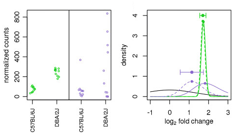

They have developed a different way to do the shrinkage and set the default to betaPrior=FALSE from version 1.16.0 onwards, where shrinkage needs to be done separately, I did not notice large differences when I tried it on some dataset so I kept betaPrior=TRUE, but it makes sense to try different approaches for different/new datasets. Then we plot an heatmap of the euclidean distances between samples and a PCA, marking human and xeno samples.

```r
dds <- DESeqDataSetFromMatrix(countData = count_data, colData = sample_sheet, design = fdesign)
# filterGenes are the genes that will be removed cause they have more than minc reads in less than min samples
filterGenes <- rowSums(counts(dds) > minc) < minsamples
dds <- dds[!filterGenes]
dds <- DESeq(dds, parallel=TRUE, betaPrior=TRUE) # https://hbctraining.github.io/DGE_workshop/lessons/05_DGE_DESeq2_analysis2.html
```

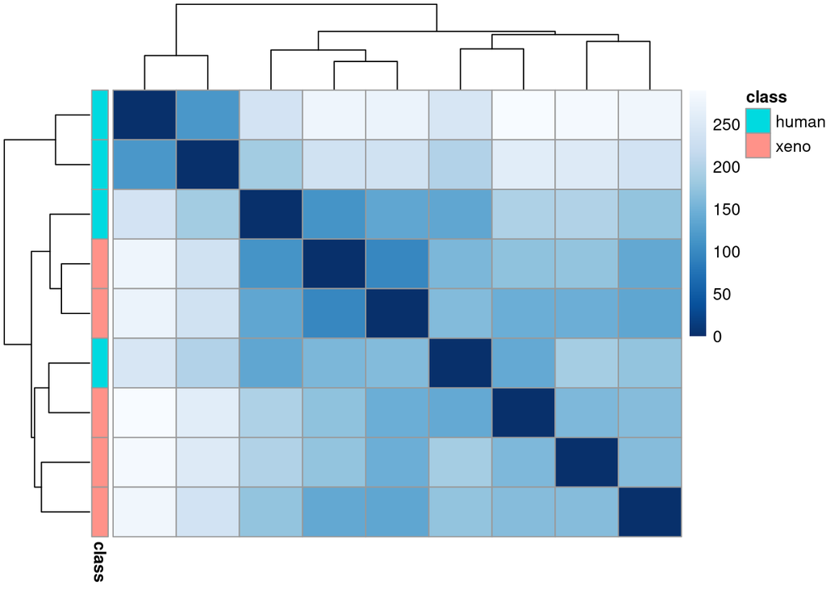

```r
# new shrinkage method suggested here: https://academic.oup.com/bioinformatics/article/35/12/2084/5159452
# accessible with betaPrior=FALSE and lfcShrink()
vsd <- vst(dds, blind=FALSE) # blind=TRUE for QA

sampleDists <- dist(t(assay(vsd)))
sampleDistMatrix <- as.matrix(sampleDists)
rownames(sampleDistMatrix) <- colnames(vsd)
colnames(sampleDistMatrix) <- NULL
colors <- colorRampPalette( rev(brewer.pal(9, "Blues")) )(255)
pheatmap(sampleDistMatrix, clustering_distance_rows=sampleDists, clustering_distance_cols=sampleDists, col=colors, annotation_row = sample_sheet[, c('class'), drop=F], show_rownames = F)
```

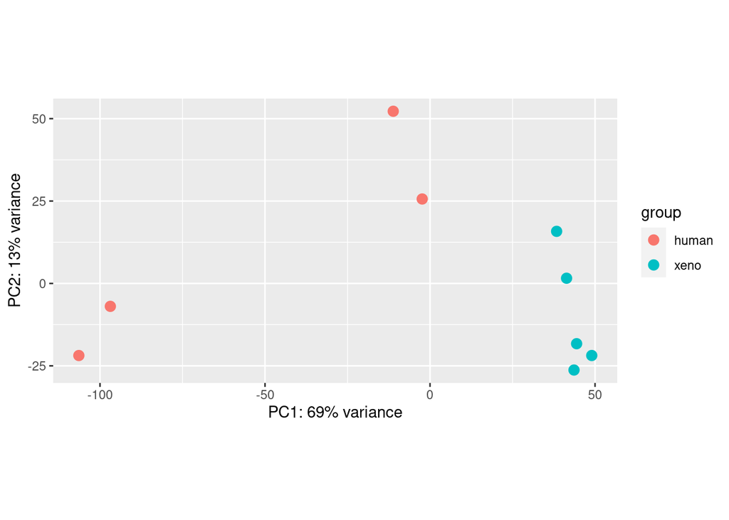

```r
plotPCA(vsd, intgroup='class')
```

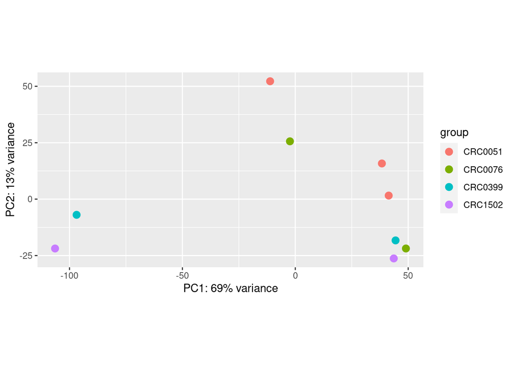

```r
plotPCA(vsd, intgroup='model')
```

## Finding the differentially expressed genes between human samples and xenografts

DESeq2 can compare, via glm, different subsets of our samples depending on how we setup our sample sheet, we need to tell him which contrast we are interested in with a vector made of: sample sheet column name and then the two levels that we want to compare. DESeq2 assign a NA pvalue to the genes with too low expression level to get a consistent statistic (this is why the initial filtering we did is useful for efficiency but not to limit our multiple test corrections).

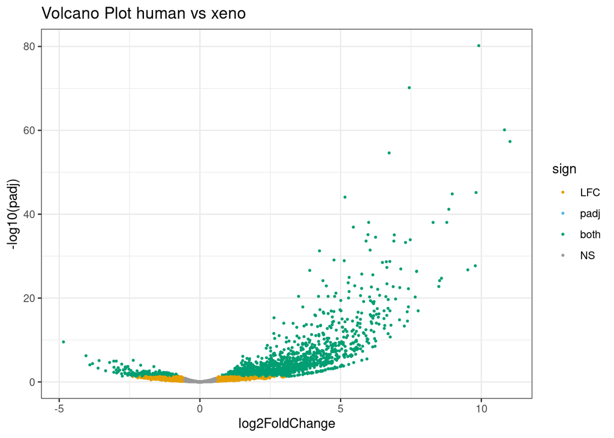

```r
lfc <- 0.58
alpha <- 0.05
res <- results(dds, alpha=alpha, contrast=c('class','human','xeno'))
resnona <- as.data.frame(res[!is.na(res$pvalue) & !is.na(res$padj),])
resnona$sign <- ifelse(abs(resnona$log2FoldChange) > lfc & resnona$padj < alpha, "both",
                       ifelse(abs(resnona$log2FoldChange) > lfc, "LFC", ifelse(resnona$padj < alpha, "padj", "NS")))
resnona$sign <- factor(resnona$sign, levels=c("LFC", "padj", "both", "NS"))
if (any(resnona$padj == 0)) {
 resnona[resnona$padj == 0, "padj"] <- .Machine$double.xmin
}
p <- ggplot(resnona, aes(log2FoldChange, -log10(padj))) +
  geom_point(aes(col = sign),size=0.5) + theme_bw() +
  scale_color_manual(values = c("#E69F00", "#56B4E9", "#009E73", "#999999"), drop=FALSE) +
  ggtitle('Volcano Plot human vs xeno')

nsign <- nrow(resnona[resnona$sig=="both",])
if (nsign > 20) {
  p + geom_text_repel(data=resnona[1:10,], aes(label=rownames(resnona)[1:10]))
} else {
  p + geom_text_repel(data=resnona[resnona$sig=="both",], aes(label=rownames(resnona[resnona$sig=="both",])))
}
```

## Normalized counts and FPKM

```r
lens <- read.table(gene_len_f, sep="\t", header=TRUE)
order <- rownames(mcols(dds))
lens <- lens[lens$Geneid %in% order,]
lens <- lens[match(order, lens$Geneid), ]
mcols(dds)$basepairs  <- lens$length
fpkm_d <- fpkm(dds, robust=TRUE) # the default
fpkm_nonorm <- fpkm(dds, robust=FALSE)
```

## Check normalizations results

```r
head(resnona[order(-resnona$log2FoldChange),])
```

```
##        baseMean log2FoldChange     lfcSE     stat       pvalue         padj
## FN1   33774.651      11.019198 0.6651349 16.56686 1.209750e-61 4.564690e-58
## BGN    3872.755      10.822696 0.6379933 16.96365 1.525606e-64 7.675322e-61
## VIM    3413.824       9.909112 0.5068776 19.54932 4.180633e-85 6.309829e-81
## THBS2  1604.416       9.812932 0.6648868 14.75880 2.700383e-49 6.792815e-46
## APOE  38239.235       9.785111 0.8428798 11.60914 3.703118e-31 1.996113e-28
## C3    94825.181       9.520308 0.8346259 11.40668 3.872392e-30 1.885355e-27
##       sign
## FN1   both
## BGN   both
## VIM   both
## THBS2 both
## APOE  both
## C3    both
```

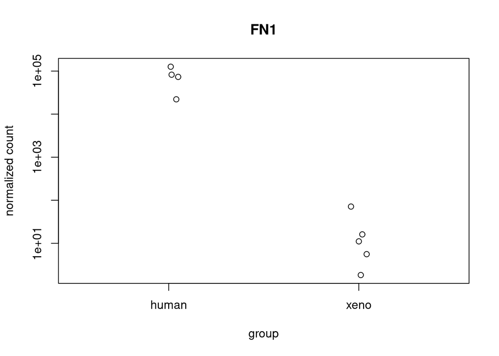

```r
plotCounts(dds, 'FN1', intgroup = 'class')
```

```r
count_data['FN1',]
```

```
##     CRC1502LMH0000000000R02000 CRC1502LMX0A02001TUMR02000
## FN1                      47107                          3
##     CRC0076LMH0000000000R02000 CRC0076LMX0B02204TUMR08000
## FN1                      19003                          1
##     CRC0399LMH0000000000R01000 CRC0399LMX0B02001TUMR04000
## FN1                      48427                         14
##     CRC0051LMH0000000000R02000 CRC0051LMX0A02201TUMR01000
## FN1                     188385                        201
##     CRC0051LMX0B01001TUMR01000
## FN1                         22
```

Let’s see if this large overexpression of many genes (e.g. Fibronectin) in the human samples makes the DESeq2 normalization for other genes better than the classic FPKM. We need to see if a genes without different expression levels looks abnormally high in xenografts due to this ‘lack of dilution’ (or the other way around).

```r
resnona['KRAS',]
```

```
##      baseMean log2FoldChange     lfcSE       stat   pvalue      padj sign
## KRAS 1058.064    -0.04964233 0.2939214 -0.1688966 0.865878 0.9269894   NS
```

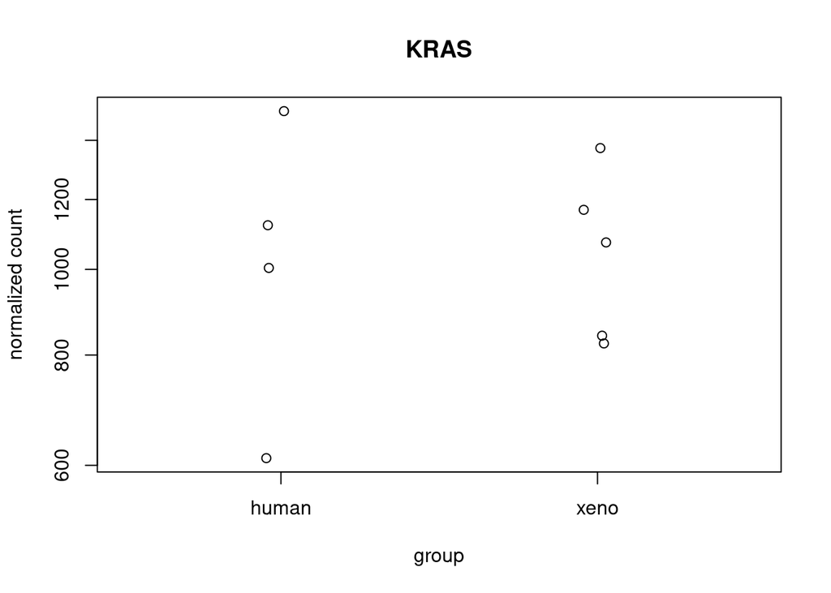

```r
plotCounts(dds, 'KRAS', intgroup = 'class')
```

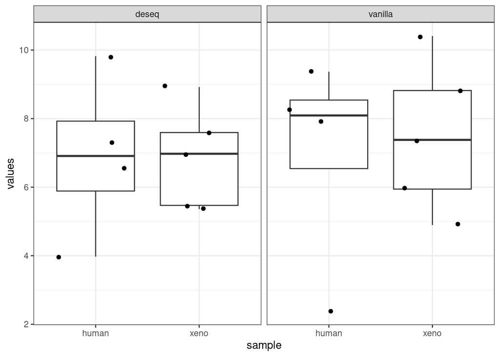

```r
norm <- fpkm_d['KRAS',]
vanilla <- fpkm_nonorm['KRAS', ]
names <- c(names(vanilla), names(norm))
pd <- data.frame(values=c(vanilla, norm),
                 method=c(rep('vanilla', length(vanilla)), rep('deseq', length(vanilla))),
                sample = ifelse(grepl('X', names), 'xeno', 'human'))
ggplot(data=pd, aes(y=values,x=sample))+geom_boxplot(outlier.shape=NA)+
  geom_jitter()+facet_wrap(~method)+theme_bw()
```

```r
round(fpkm_d['FN1',], 4)
```

```
## CRC1502LMH0000000000R02000 CRC1502LMX0A02001TUMR02000
##                   659.0349                     0.0266
## CRC0076LMH0000000000R02000 CRC0076LMX0B02204TUMR08000
##                   115.3316                     0.0070
## CRC0399LMH0000000000R01000 CRC0399LMX0B02001TUMR04000
##                   430.1037                     0.0815
## CRC0051LMH0000000000R02000 CRC0051LMX0A02201TUMR01000
##                   382.2593                     0.3699
## CRC0051LMX0B01001TUMR01000
##                     0.0553
```

```r
round(fpkm_nonorm['KRAS',], 4)
```

```
## CRC1502LMH0000000000R02000 CRC1502LMX0A02001TUMR02000
##                     2.4138                     4.8952
## CRC0076LMH0000000000R02000 CRC0076LMX0B02204TUMR08000
##                     9.3688                     7.3805
## CRC0399LMH0000000000R01000 CRC0399LMX0B02001TUMR04000
##                     7.9198                    10.4087
## CRC0051LMH0000000000R02000 CRC0051LMX0A02201TUMR01000
##                     8.2655                     8.8201
## CRC0051LMX0B01001TUMR01000
##                     5.9445
```

## Hallmark GSEA analysis with clusterProfiler

clusterProfiler is a package that offers many functions to perform GO/GSEA analysis and plot results. Here we’ll just check the Hallmark curated collection of gene sets using our log2FoldChange to rank the genes for the GSEA analysis and look at enrichment plots for some manually selected gene sets.

```r
geneList <- resnona$log2FoldChange
names(geneList) <- rownames(resnona)
geneList <- sort(geneList, decreasing = TRUE)


# downloading the msigdbr collection takes a little bit of time, so we skip it for the lab and load the rds object I had previously
# obtained and saved with the following code:
#msig <- getMsigdb(org = 'hs', id = 'SYM', version = '7.4')
#hallm <- subsetCollection(msig, 'h')
#list_hall <- geneIds(hallm)
#h_t2g <- t(as.data.frame(sapply(names(list_hall), function(x) { t(data.frame(gs=rep(x, length(list_hall[[x]])),symbol=list_hall[[x]])) })))
#saveRDS(h_t2g, file=hallmark_rds)
h_t2g <- readRDS(hallmark_rds)

gsea_h <-  GSEA(geneList, TERM2GENE=h_t2g, pvalueCutoff = 1, nPermSimple = 10000)
```

```
## preparing geneSet collections...
```

```
## GSEA analysis...
```

```
## leading edge analysis...
```

```
## done...
```

```r
head(gsea_h@result)
```

```
##                                                                                    ID
## HALLMARK_E2F_TARGETS                                             HALLMARK_E2F_TARGETS
## HALLMARK_MYC_TARGETS_V1                                       HALLMARK_MYC_TARGETS_V1
## HALLMARK_G2M_CHECKPOINT                                       HALLMARK_G2M_CHECKPOINT
## HALLMARK_EPITHELIAL_MESENCHYMAL_TRANSITION HALLMARK_EPITHELIAL_MESENCHYMAL_TRANSITION
## HALLMARK_COAGULATION                                             HALLMARK_COAGULATION
## HALLMARK_COMPLEMENT                                               HALLMARK_COMPLEMENT
##                                                                           Description
## HALLMARK_E2F_TARGETS                                             HALLMARK_E2F_TARGETS
## HALLMARK_MYC_TARGETS_V1                                       HALLMARK_MYC_TARGETS_V1
## HALLMARK_G2M_CHECKPOINT                                       HALLMARK_G2M_CHECKPOINT
## HALLMARK_EPITHELIAL_MESENCHYMAL_TRANSITION HALLMARK_EPITHELIAL_MESENCHYMAL_TRANSITION
## HALLMARK_COAGULATION                                             HALLMARK_COAGULATION
## HALLMARK_COMPLEMENT                                               HALLMARK_COMPLEMENT
##                                            setSize enrichmentScore       NES
## HALLMARK_E2F_TARGETS                           198      -0.6285983 -3.195628
## HALLMARK_MYC_TARGETS_V1                        193      -0.5765718 -2.861337
## HALLMARK_G2M_CHECKPOINT                        192      -0.5159238 -2.546327
## HALLMARK_EPITHELIAL_MESENCHYMAL_TRANSITION     150       0.7934523  2.349111
## HALLMARK_COAGULATION                            94       0.7826156  2.259546
## HALLMARK_COMPLEMENT                            157       0.7057973  2.094102
##                                            pvalue     p.adjust       qvalue
## HALLMARK_E2F_TARGETS                        1e-10 4.166667e-10 1.666667e-10
## HALLMARK_MYC_TARGETS_V1                     1e-10 4.166667e-10 1.666667e-10
## HALLMARK_G2M_CHECKPOINT                     1e-10 4.166667e-10 1.666667e-10
## HALLMARK_EPITHELIAL_MESENCHYMAL_TRANSITION  1e-10 4.166667e-10 1.666667e-10
## HALLMARK_COAGULATION                        1e-10 4.166667e-10 1.666667e-10
## HALLMARK_COMPLEMENT                         1e-10 4.166667e-10 1.666667e-10
##                                            rank                   leading_edge
## HALLMARK_E2F_TARGETS                       3269 tags=60%, list=22%, signal=48%
## HALLMARK_MYC_TARGETS_V1                    4695 tags=67%, list=31%, signal=47%
## HALLMARK_G2M_CHECKPOINT                    1963 tags=45%, list=13%, signal=40%
## HALLMARK_EPITHELIAL_MESENCHYMAL_TRANSITION 1604 tags=55%, list=11%, signal=49%
## HALLMARK_COAGULATION                       1998 tags=56%, list=13%, signal=49%
## HALLMARK_COMPLEMENT                        2330 tags=44%, list=15%, signal=38%
##                                                                                                                                                                                                                                                                                                          …
## HALLMARK_E2F_TARGETS                                                                   ATAD2/RAD1/ESPL1/WDR90/CBX5/NOLC1/HNRNPD/BRCA1/POLE4/NUP107/…
## HALLMARK_MYC_TARGETS_V1                    ODC1/EIF4E/ORC2/C1QBP/RPS10/CAD/GSPT1/VBP1/SF3B3/EIF1AX/PRPF…
## HALLMARK_G2M_CHECKPOINT                                                                                                                                                                                                                                                                               UCK…
## HALLMARK_EPITHELIAL_MESENCHYMAL_TRANSITION                                                                                                                                                                                                                                                               …
## HALLMARK_COAGULATION                                                                                                                                                                                                                                                                                     …
## HALLMARK_COMPLEMENT                                                                                                                                                                                                                                                                                      …
```

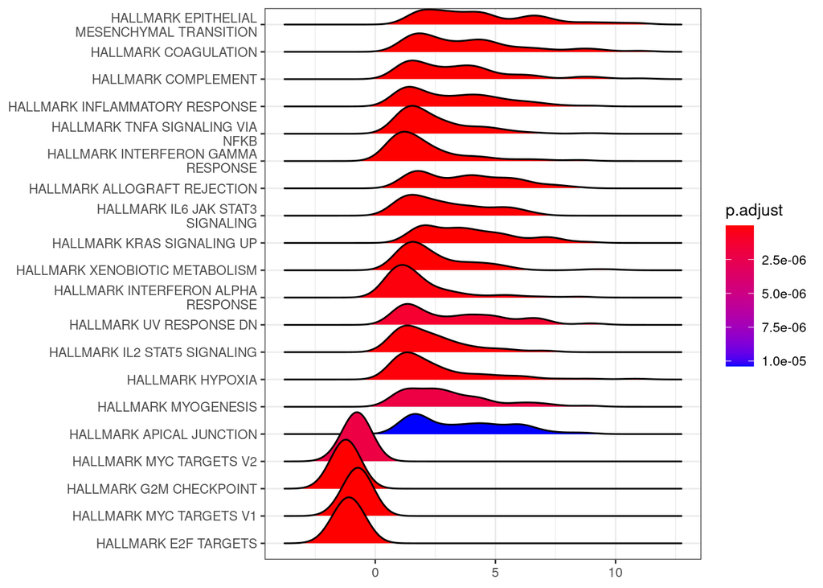

```r
ridgeplot(gsea_h, showCategory = 20)+theme_bw(base_size=10)
```

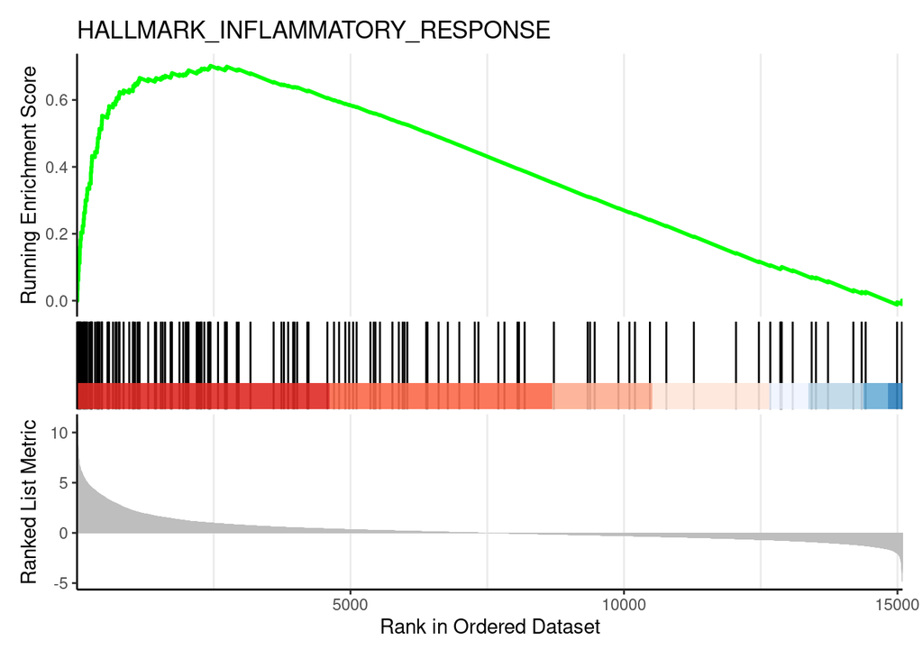

```r
w1 <- which(gsea_h@result['ID']=="HALLMARK_INFLAMMATORY_RESPONSE")
w2 <- which(gsea_h@result['ID']=="HALLMARK_E2F_TARGETS")
gseaplot2(gsea_h, geneSetID = w1, title=gsea_h@result['ID'][w1,])
```

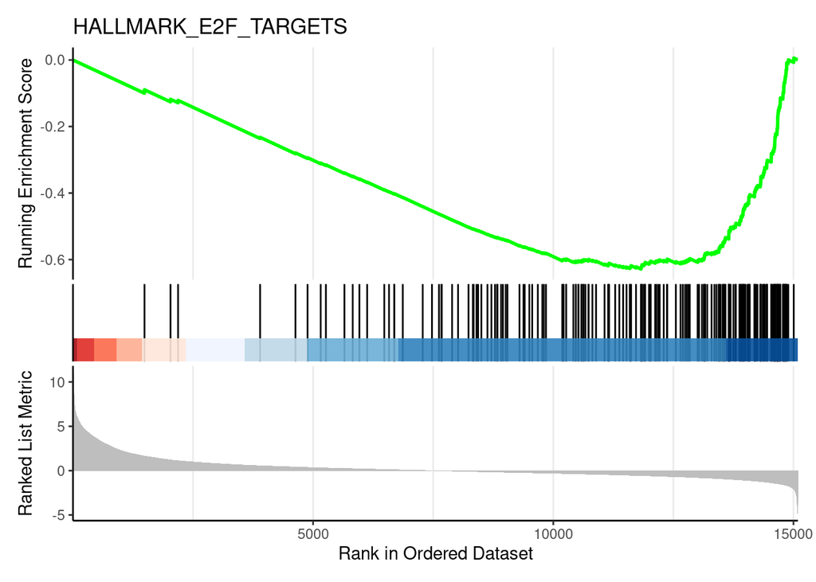

```r
gseaplot2(gsea_h, geneSetID = w2, title=gsea_h@result['ID'][w2,])
```